# My Exercise 3

Rockefeller University, Bioinformatics Resource Centre

https://rockefelleruniversity.github.io/RU_course_template/

```
## Using virtual environment '/github/home/.virtualenvs/r-reticulate' ...
```

**Exercise: Putting it all together with DataVis**

We have learned how to write many lines of code to generate and customize a single figure. This is nice, but we want to be practical. In fact, you can put all of your plotting code inside a function that will allow you to automate the production of figures within your workflows. This way, you can call this function with different datasets and it will return a consistently-formatted plot for each.

The following is an exercise that should bring together many of the concepts that you have learned over the past two days. You will:

1. Import data from a csv file
2. Manipulate the data by separating it into subsets
3. Write a function that generates a plot
4. Use a for loop to automaticalyl generate a plot for each subset of data

The data we will be working with is gene expression data. There are a number of genes listed, and each gene has an associated expression and length, as well as a Gene Ontology (GO) term. The first task will be to read in the data using `genfromtxt()`. The data is stored in the file called “gene_expression.csv”.

The data is arranged as follows:

| geneName | expression | geneLength | goterm |
| --- | --- | --- | --- |
| Gene_1 | 2560 | 20 | GO:Biosynthetic Process |
| … | … | … | … |

The geneName category ranges from Gene_1 to Gene_30. expression and geneLength are numerical values, and goterm is a string with possible values “GO:Biosynthetic Process”, “GO:Metabolic Process” and “GO:Catabolic Process”.

First, import this data into numpy arrays. You should have four arrays, one for each column. Hont: You may have to specify the `dtype` and `encoding` options (as shown before) to deal with the variety of data types.

```python
## Add the solution in here. This will only be included in the exercise sections. This is controlled by the echo=toMessage in the markdown header  ie:

name, expression, length, goterm = np.genfromtxt('data/gene_expression.csv', unpack=True, delimiter=',', skip_header=True, dtype=None, encoding='UTF-8')
```

Now that we have the data, we need to sort it. We want to make a separate plot for each GO term (Biosynthetic, Metabolic, and Catabolic Processes). Create empty lists for the gene names, expressions, and lengths for each GO term. For example:

```python
name_bio = []
exp_bio = []
len_bio = []
... and so on
```

Then, use a for loop to go through the unsorted data and append each value ot the correct list.

```python
for i=0 to 29: #remember 0-indexing
  if goterm[i] == "GO:Biosynthetic Process":
    append name[i] to name_bio
    etc
  elif goterm[i] == "GO:Metabolic Process":
    etc
  else:
    etc
```

```python
name_bio = []
exp_bio = []
len_bio = []

name_meta = []
exp_meta = []
len_meta = []

name_cat = []
exp_cat = []
len_cat = []

for i in range(len(name)):
  if goterm[i] == "GO:Biosynthetic Process":
    name_bio.append(name[i])
    exp_bio.append(expression[i])
    len_bio.append(length[i])
  elif goterm[i] == "GO:Metabolic Process":
    name_meta.append(name[i])
    exp_meta.append(expression[i])
    len_meta.append(length[i])
  else:
    name_cat.append(name[i])
    exp_cat.append(expression[i])
    len_cat.append(length[i])
```

You should now have 9 lists, each of length 10, corresponding to the sorted data. Try printing the lists, and their lengths, to make sure you have everything sorted properly.

Now, we will write some code that will plot one of the datasets (let’s choose the Biosynthetic Process dataset). We are going to generate a scatter plot of Expression vs Length. Choose whatever colors and markers you’d like, and be sure to include a title and axis labels.

[figure not shown]

```python
fig, ax = plt.subplots(figsize = (4,3))
ax.scatter(exp_bio, len_bio, c = "lightgreen")
ax.set_xlabel("Gene Expression")
ax.set_ylabel("Gene Length")
ax.set_title("Biosynthetic Processes")
plt.show()
```

Once you have code that generates a nice figure, let’s put it inside a function. Define a function that takes three variables: the `x data` and `y data` to be plotted, and the `name` you would like to save the figure as. This function should plot the data and save the plot with the specified name.

Hint: think about how you can use string operations to automatically generate a title for your plot as well as a file name!

```python
def plot_data(xdata, ydata, name):
  fig, ax = plt.subplots(figsize = (4,3))
  ax.scatter(xdata, ydata, c = "lightgreen")
  ax.set_xlabel("Gene Expression")
  ax.set_ylabel("Gene Length")
  ax.set_title(name)
  fig.tight_layout()
  fig.savefig(name + ".pdf", bbox_inches='tight')
```

Now that you have a function, we would like to call it to plot the data. Create a for loop that will iterate over the three datasets and plot them.

Hint: You may need to create some new lists to store the `name` parameter, as well as the data lists you would like to iterate over.

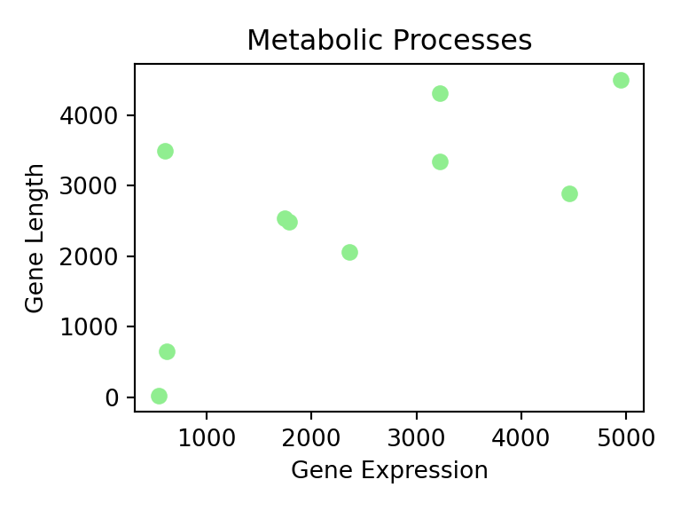

```python
xdata = [exp_bio, exp_cat, exp_meta]
ydata = [len_bio, len_cat, len_meta]
names = ["Biosynthetic Processes", "Catabolic Processes", "Metabolic Processes"]

for i in range(len(xdata)):
  plot_data(xdata[i], ydata[i], names[i])
```

We want to be able to compare our data directly - let’s make all of them plotted on the same scale. Set vertical and horizontal axis limits of (-200, 5200). You will need to edit your function and caLL it again.

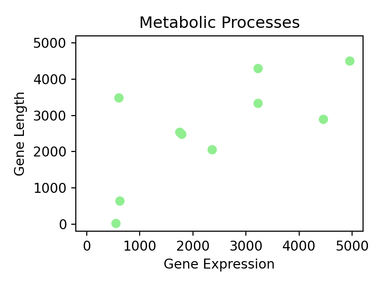

```python
def plot_data(xdata, ydata, name):
  fig, ax = plt.subplots(figsize = (4,3))
  ax.scatter(xdata, ydata, c = "lightgreen")
  ax.set_xlabel("Gene Expression")
  ax.set_ylabel("Gene Length")
  ax.set_title(name)
  ax.set_xlim(-200, 5200)
  ax.set_ylim(-200, 5200)
  fig.tight_layout()
  fig.savefig(name + ".pdf", bbox_inches='tight')

for i in range(len(xdata)):
  plot_data(xdata[i], ydata[i], names[i])
```